# What is Project 101?

- 서바이벌 방송 프로그램 프로듀스101(m-net)의 데이터 분석 및 결과 추정
- Analyze TV show named Produce101 (Estimate your girls)

[figure not shown]

# What is Project 101?

- 서바이벌 방송 프로그램 프로듀스101(m-net)의 데이터 분석 및 결과 추정
- Analyze TV show named Produce101 (Estimate your girls)

[figure not shown]

# Data

- [crawling from m-net webpage](http://mnettv.interest.me/produce101/page/p101.page.profile.dbp?id=88)
- put into dataframe with the Python

# Data

### 1. SAMPLE : 97 people (retire 4 people)

### 2. TAGET (Y)

- votes : 엠넷 홈페이지에서 1일 1명당 11표
- votes : on m-net webpage with 1 person 11 votes in every day)

### 3. FEATURE (X1, X2, ..., X12)

- expo_1 : 1차 방출평가 전에 Produce101 방송된 1회~4회까지 각 연습생의 방송 노출 시간
- expo_2 : 2차 방출평가 전에 Produce101 방송된 5회~7회까지 각 연습생의 방송 노출 시간
  - (출처 : [방송모니터위원회]Mnet 오디션 프로그램 <프로듀스 101> 모니터보고서(2016.3.25))
- neg_1 : 1,2회 / 방송 후 부정적 여론 형성 (허찬미 : 인사 안함 논란, 1위자리 앉음 | 오서정 : 슈퍼스타K 안예슬 논란) [category]
- order_name : 투표 홈페이지 이름 순으로 상위 11명 노출 여부 [category]
- order_agency : 투표 홈페이지 소속사 순으로 상위 11명 노출 여부 [category]
- level_1 : 1회, 2회 / 1차 레벨 평가 테스트 후 판정 (A:5 / B:4 / C:3 / D:2 / F:1) [category]
- level_2 : 2회 / 2차 레벨 평가 테스트 후 판정 (A:5 / B:4 / C:3 / D:2 / F:1) [category]
- age : 나이
- height : 신장
- visual : 연습생들이 직접 뽑은 비주얼 1~11위 [category]
- agency_category : 소속 연예기획사 카테고리값 (대형:3 / 중소형:2 / 개인:1) [category]
  - 연예 전문 웹진 분류 참고 : http://ize.co.kr/articleView.html?no=2016022121027299563
- agency_member_count : 같은 소속사 연습생 수
- is_ranker_same_agency_1 : 1차 방출평가 시 같은 소속사 연습생이 상위 11위에 포함되어 있는가? (Hard Carry) [category]
- is_ranker_same_agency_2 : 2차 방출평가 시 같은 소속사 연습생이 상위 11위에 포함되어 있는가? (Hard Carry) [category]

# EDA(Exploratory data analysis)

```python
produce101_df = pd.DataFrame.from_csv("produce101_raw.csv",
                                      index_col='name', encoding='utf-8')
produce101_df
```

| name | agency | vote_1 | vote_2 | expo_1 | expo_2 | imp_1 | imp_2 | neg_1 | order_name | order_agency | ... | level_2 | age | height | visual | agency_category | id | thumb_pic_url | agency_member_count | is_ranker_same_agency_1 | is_ranker_same_agency_2 |
| --- | --- | --- | --- | --- | --- | --- | --- | --- | --- | --- | --- | --- | --- | --- | --- | --- | --- | --- | --- | --- | --- |
| 김세정 | Jellyfish(젤리피쉬) | 559694 | 1473685 | 105 | 104 | 39 | 8 | 0 | 0 | 0 | ... | 5 | 20 | 164.0 | 1 | 3 | 88 | http://static.global.mnet.com/data/od/images/g... | 3 | 1 | 1 |
| 전소미 | JYP | 528772 | 1201490 | 171 | 63 | 49 | 21 | 0 | 0 | 0 | ... | 4 | 15 | 168.0 | 1 | 3 | 40 | http://static.global.mnet.com/data/od/images/g... | 1 | 0 | 0 |
| 최유정 | 판타지오 | 392773 | 1286447 | 134 | 71 | 10 | 50 | 0 | 0 | 0 | ... | 5 | 17 | 159.0 | 0 | 3 | 42 | http://static.global.mnet.com/data/od/images/g... | 5 | 1 | 1 |
| 주결경 | PLEDIS(플레디스) | 387537 | 885556 | 6 | 31 | 13 | 3 | 0 | 0 | 0 | ... | 5 | 18 | 166.0 | 1 | 3 | 136 | http://static.global.mnet.com/data/od/images/g... | 7 | 1 | 1 |
| 강미나 | Jellyfish(젤리피쉬) | 376977 | 1212720 | 34 | 100 | 33 | 8 | 0 | 1 | 0 | ... | 5 | 17 | 162.0 | 0 | 3 | 90 | http://static.global.mnet.com/data/od/images/g... | 3 | 1 | 1 |
| 기희현 | MBK | 294540 | 481070 | 91 | 19 | 26 | 5 | 0 | 1 | 0 | ... | 5 | 21 | 167.0 | 1 | 3 | 187 | http://static.global.mnet.com/data/od/images/g... | 3 | 1 | 1 |
| 김다니 | MBK | 273930 | 419427 | 52 | 9 | 28 | 1 | 0 | 1 | 0 | ... | 5 | 17 | 172.0 | 0 | 3 | 186 | http://static.global.mnet.com/data/od/images/g... | 3 | 1 | 1 |
| 정채연 | MBK | 251469 | 696808 | 10 | 34 | 21 | 4 | 0 | 0 | 0 | ... | 3 | 19 | 166.0 | 1 | 3 | 185 | http://static.global.mnet.com/data/od/images/g... | 3 | 1 | 1 |
| 김나영 | Jellyfish(젤리피쉬) | 250552 | 931084 | 65 | 44 | 28 | 5 | 0 | 1 | 0 | ... | 5 | 21 | 169.0 | 0 | 3 | 89 | http://static.global.mnet.com/data/od/images/g... | 3 | 1 | 1 |
| 전소연 | CUBE | 230395 | 372952 | 54 | 27 | 33 | 8 | 0 | 0 | 1 | ... | 5 | 18 | 157.0 | 0 | 3 | 162 | http://static.global.mnet.com/data/od/images/g... | 3 | 1 | 0 |
| 김소혜 | REDLINE(레드라인) | 227670 | 833101 | 163 | 128 | 40 | 15 | 0 | 0 | 0 | ... | 1 | 17 | 163.0 | 0 | 2 | 72 | http://static.global.mnet.com/data/od/images/g... | 1 | 0 | 0 |
| 유연정 | 스타쉽 | 214691 | 684660 | 58 | 54 | 8 | 1 | 0 | 0 | 0 | ... | 5 | 17 | 167.0 | 0 | 3 | 63 | http://static.global.mnet.com/data/od/images/g... | 3 | 0 | 1 |
| 김도연 | 판타지오 | 203007 | 841749 | 39 | 3 | 12 | 27 | 0 | 0 | 0 | ... | 5 | 17 | 170.0 | 1 | 3 | 45 | http://static.global.mnet.com/data/od/images/g... | 5 | 1 | 1 |
| 김청하 | M&H | 193820 | 462668 | 69 | 15 | 5 | 54 | 0 | 0 | 0 | ... | 5 | 20 | 161.0 | 0 | 2 | 103 | http://static.global.mnet.com/data/od/images/g... | 2 | 0 | 0 |
| 허찬미 | 더블킥 | 184926 | 249026 | 133 | 36 | 63 | 11 | 1 | 0 | 0 | ... | 4 | 24 | 161.0 | 0 | 2 | 188 | http://static.global.mnet.com/data/od/images/g... | 1 | 0 | 0 |
| 권은빈 | CUBE | 179721 | 310972 | 43 | 32 | 29 | 4 | 0 | 1 | 1 | ... | 2 | 16 | 167.0 | 1 | 3 | 164 | http://static.global.mnet.com/data/od/images/g... | 3 | 1 | 0 |
| 응 씨 카이 | 초록뱀주나 | 176067 | 298495 | 4 | 52 | 3 | 87 | 0 | 0 | 0 | ... | 4 | 22 | 165.0 | 0 | 2 | 202 | http://static.global.mnet.com/data/od/images/g... | 1 | 0 | 0 |
| 정은우 | PLEDIS(플레디스) | 175904 | 438879 | 7 | 26 | 5 | 3 | 0 | 0 | 0 | ... | 4 | 18 | 167.0 | 0 | 3 | 137 | http://static.global.mnet.com/data/od/images/g... | 7 | 1 | 1 |
| 김주나 | music K | 161825 | 371978 | 202 | 62 | 40 | 23 | 0 | 0 | 0 | ... | 1 | 22 | 168.0 | 0 | 2 | 218 | http://static.global.mnet.com/data/od/images/g... | 1 | 0 | 0 |
| 박소연 | LOEN (로엔) | 156148 | 289217 | 32 | 35 | 14 | 85 | 0 | 0 | 0 | ... | 5 | 17 | 168.0 | 0 | 3 | 165 | http://static.global.mnet.com/data/od/images/g... | 1 | 0 | 0 |
| 윤채경 | DSP | 149977 | 460700 | 43 | 66 | 23 | 6 | 0 | 0 | 1 | ... | 3 | 20 | 160.0 | 0 | 3 | 62 | http://static.global.mnet.com/data/od/images/g... | 2 | 0 | 0 |
| 한혜리 | Star Empire(스타제국) | 125095 | 450768 | 16 | 13 | 1 | 33 | 0 | 0 | 0 | ... | 2 | 19 | 159.0 | 0 | 3 | 91 | http://static.global.mnet.com/data/od/images/g... | 3 | 0 | 0 |
| 김소희 | 뮤직웍스 | 109501 | 363818 | 16 | 13 | 9 | 2 | 0 | 0 | 0 | ... | 3 | 21 | 162.0 | 0 | 2 | 197 | http://static.global.mnet.com/data/od/images/g... | 1 | 0 | 0 |
| 임나영 | PLEDIS(플레디스) | 107785 | 665898 | 24 | 18 | 7 | 1 | 0 | 0 | 0 | ... | 5 | 21 | 171.0 | 0 | 3 | 138 | http://static.global.mnet.com/data/od/images/g... | 7 | 1 | 1 |
| 안예슬 | MAJESTY(마제스티) | 106322 | 301814 | 34 | 65 | 4 | 46 | 0 | 0 | 0 | ... | 4 | 21 | 161.0 | 0 | 2 | 100 | http://static.global.mnet.com/data/od/images/g... | 2 | 0 | 0 |
| 박시연 | PLEDIS(플레디스) | 105963 | 372295 | 16 | 61 | 7 | 0 | 0 | 0 | 0 | ... | 4 | 16 | 163.0 | 1 | 3 | 139 | http://static.global.mnet.com/data/od/images/g... | 7 | 1 | 1 |
| 조시윤 | DSP | 102110 | 146681 | 25 | 7 | 22 | 9 | 0 | 0 | 1 | ... | 2 | 20 | 160.0 | 0 | 3 | 61 | http://static.global.mnet.com/data/od/images/g... | 2 | 0 | 0 |
| 강예빈 | PLEDIS(플레디스) | 88277 | 250556 | 62 | 19 | 14 | 3 | 0 | 1 | 0 | ... | 5 | 18 | 162.5 | 0 | 3 | 141 | http://static.global.mnet.com/data/od/images/g... | 7 | 1 | 1 |
| 윤서형 | &August(&어거스트) | 73558 | 187021 | 198 | 4 | 55 | 1 | 0 | 0 | 1 | ... | 2 | 21 | 163.0 | 0 | 2 | 74 | http://static.global.mnet.com/data/od/images/g... | 1 | 0 | 0 |
| 김서경 | 개인연습생 | 72474 | 300125 | 42 | 18 | 0 | 8 | 0 | 0 | 0 | ... | 5 | 17 | 155.0 | 0 | 1 | 169 | http://static.global.mnet.com/data/od/images/g... | 1 | 0 | 0 |
| ... | ... | ... | ... | ... | ... | ... | ... | ... | ... | ... | ... | ... | ... | ... | ... | ... | ... | ... | ... | ... | ... |
| 김지성 | Happyface | 26566 | 0 | 0 | 0 | 1 | 0 | 0 | 0 | 0 | ... | 4 | 20 | 169.0 | 1 | 2 | 147 | http://static.global.mnet.com/data/od/images/g... | 8 | 0 | 0 |
| 김수현 | 미스틱 | 26139 | 0 | 11 | 0 | 1 | 0 | 0 | 0 | 0 | ... | 2 | 16 | 161.0 | 0 | 2 | 166 | http://static.global.mnet.com/data/od/images/g... | 1 | 0 | 0 |
| 최은빈 | 넥스타 | 25659 | 0 | 32 | 0 | 1 | 9 | 0 | 0 | 0 | ... | 3 | 23 | 163.0 | 0 | 2 | 198 | http://static.global.mnet.com/data/od/images/g... | 2 | 0 | 0 |
| 박민지 | 매직 프레쉬컴퍼니 | 24772 | 0 | 12 | 0 | 3 | 5 | 0 | 0 | 0 | ... | 5 | 17 | 164.0 | 0 | 2 | 174 | http://static.global.mnet.com/data/od/images/g... | 2 | 0 | 0 |
| 함예지 | 스타플레닛 | 24485 | 0 | 14 | 0 | 8 | 6 | 0 | 0 | 0 | ... | 1 | 22 | 167.3 | 0 | 2 | 222 | http://static.global.mnet.com/data/od/images/g... | 1 | 0 | 0 |
| 김미소 | MJ | 24114 | 0 | 38 | 0 | 0 | 1 | 0 | 0 | 0 | ... | 3 | 16 | 165.0 | 0 | 2 | 55 | http://static.global.mnet.com/data/od/images/g... | 3 | 0 | 0 |
| 김우정 | Happyface | 23795 | 0 | 51 | 0 | 1 | 0 | 0 | 0 | 0 | ... | 3 | 24 | 162.0 | 0 | 2 | 149 | http://static.global.mnet.com/data/od/images/g... | 8 | 0 | 0 |
| 허샘 | MJ | 23722 | 0 | 8 | 0 | 1 | 2 | 0 | 0 | 0 | ... | 1 | 23 | 166.0 | 0 | 2 | 53 | http://static.global.mnet.com/data/od/images/g... | 3 | 0 | 0 |
| 한지연 | MIDAS(마이다스) | 23566 | 0 | 2 | 0 | 1 | 3 | 0 | 0 | 0 | ... | 1 | 21 | 167.0 | 0 | 2 | 94 | http://static.global.mnet.com/data/od/images/g... | 6 | 0 | 0 |
| 니와 시오리 | MAJESTY(마제스티) | 23045 | 0 | 0 | 0 | 2 | 8 | 0 | 0 | 0 | ... | 4 | 22 | 162.0 | 0 | 2 | 101 | http://static.global.mnet.com/data/od/images/g... | 2 | 0 | 0 |
| 편강윤 | M2 project | 21908 | 0 | 4 | 0 | 4 | 0 | 0 | 0 | 0 | ... | 1 | 24 | 167.8 | 0 | 2 | 223 | http://static.global.mnet.com/data/od/images/g... | 1 | 0 | 0 |
| 이수현 | Happyface | 21762 | 0 | 26 | 0 | 2 | 0 | 0 | 0 | 0 | ... | 4 | 20 | 161.0 | 1 | 2 | 145 | http://static.global.mnet.com/data/od/images/g... | 8 | 0 | 0 |
| 김홍은 | Happyface | 21598 | 0 | 1 | 0 | 0 | 0 | 0 | 0 | 0 | ... | 1 | 17 | 170.0 | 0 | 2 | 146 | http://static.global.mnet.com/data/od/images/g... | 8 | 0 | 0 |
| 김도희 | 블레싱 | 21485 | 0 | 8 | 0 | 0 | 2 | 0 | 0 | 0 | ... | 1 | 19 | 165.0 | 0 | 2 | 193 | http://static.global.mnet.com/data/od/images/g... | 5 | 0 | 0 |
| 김설아 | 이큐브 미디어 | 21394 | 0 | 2 | 0 | 3 | 0 | 0 | 0 | 0 | ... | 1 | 25 | 163.0 | 0 | 2 | 176 | http://static.global.mnet.com/data/od/images/g... | 1 | 0 | 0 |
| 오한아름 | 블레싱 | 21245 | 0 | 9 | 0 | 0 | 2 | 0 | 0 | 0 | ... | 1 | 18 | 162.0 | 0 | 2 | 189 | http://static.global.mnet.com/data/od/images/g... | 5 | 0 | 0 |
| 김윤지 | Star Empire(스타제국) | 21206 | 0 | 43 | 0 | 0 | 23 | 0 | 0 | 0 | ... | 4 | 20 | 156.0 | 0 | 3 | 92 | http://static.global.mnet.com/data/od/images/g... | 3 | 0 | 0 |
| 이서정 | LOUDers(라우더스) | 21018 | 0 | 3 | 0 | 0 | 0 | 0 | 0 | 0 | ... | 2 | 16 | 163.0 | 0 | 2 | 195 | http://static.global.mnet.com/data/od/images/g... | 3 | 0 | 0 |
| 김자연 | Happyface | 20932 | 0 | 13 | 0 | 0 | 1 | 0 | 0 | 0 | ... | 2 | 25 | 164.0 | 0 | 2 | 148 | http://static.global.mnet.com/data/od/images/g... | 8 | 0 | 0 |
| 이채린 | MIDAS(마이다스) | 20868 | 0 | 1 | 0 | 0 | 3 | 0 | 0 | 0 | ... | 2 | 17 | 162.0 | 0 | 2 | 97 | http://static.global.mnet.com/data/od/images/g... | 6 | 0 | 0 |
| 최유빈 | MIDAS(마이다스) | 20829 | 0 | 8 | 0 | 1 | 3 | 0 | 0 | 0 | ... | 2 | 17 | 161.0 | 0 | 2 | 96 | http://static.global.mnet.com/data/od/images/g... | 6 | 0 | 0 |
| 캐서린 리 | MIDAS(마이다스) | 20807 | 0 | 2 | 0 | 1 | 3 | 0 | 0 | 0 | ... | 1 | 15 | 165.0 | 0 | 2 | 95 | http://static.global.mnet.com/data/od/images/g... | 6 | 0 | 0 |
| 신혜현 | MIDAS(마이다스) | 20752 | 0 | 7 | 0 | 0 | 1 | 0 | 0 | 0 | ... | 3 | 17 | 162.0 | 0 | 2 | 98 | http://static.global.mnet.com/data/od/images/g... | 6 | 0 | 0 |
| 남수진 | 매직 프레쉬컴퍼니 | 20189 | 0 | 0 | 0 | 0 | 6 | 0 | 0 | 0 | ... | 3 | 21 | 168.0 | 0 | 2 | 175 | http://static.global.mnet.com/data/od/images/g... | 2 | 0 | 0 |
| 김솔이 | 블레싱 | 19899 | 0 | 6 | 0 | 0 | 0 | 0 | 0 | 0 | ... | 1 | 15 | 172.7 | 0 | 2 | 192 | http://static.global.mnet.com/data/od/images/g... | 5 | 0 | 0 |
| 이세흔 | NEXTLEVEL(넥스트레벨) | 18731 | 0 | 21 | 0 | 1 | 8 | 0 | 0 | 0 | ... | 3 | 17 | 159.0 | 0 | 2 | 73 | http://static.global.mnet.com/data/od/images/g... | 1 | 0 | 0 |
| 방준희 | 블레싱 | 18579 | 0 | 10 | 0 | 0 | 0 | 0 | 0 | 0 | ... | 3 | 18 | 164.0 | 0 | 2 | 191 | http://static.global.mnet.com/data/od/images/g... | 5 | 0 | 0 |
| 윤유담 | FM | 18206 | 0 | 23 | 0 | 0 | 9 | 0 | 0 | 1 | ... | 2 | 19 | 168.0 | 0 | 2 | 226 | http://static.global.mnet.com/data/od/images/g... | 1 | 0 | 0 |
| 김보선 | LOUDers(라우더스) | 18034 | 0 | 18 | 0 | 2 | 0 | 0 | 0 | 0 | ... | 2 | 22 | 163.0 | 0 | 2 | 196 | http://static.global.mnet.com/data/od/images/g... | 3 | 0 | 0 |
| 문현주 | 넥스타 | 16736 | 0 | 13 | 0 | 0 | 0 | 0 | 0 | 0 | ... | 1 | 18 | 170.0 | 0 | 2 | 199 | http://static.global.mnet.com/data/od/images/g... | 2 | 0 | 0 |

97 rows × 21 columns

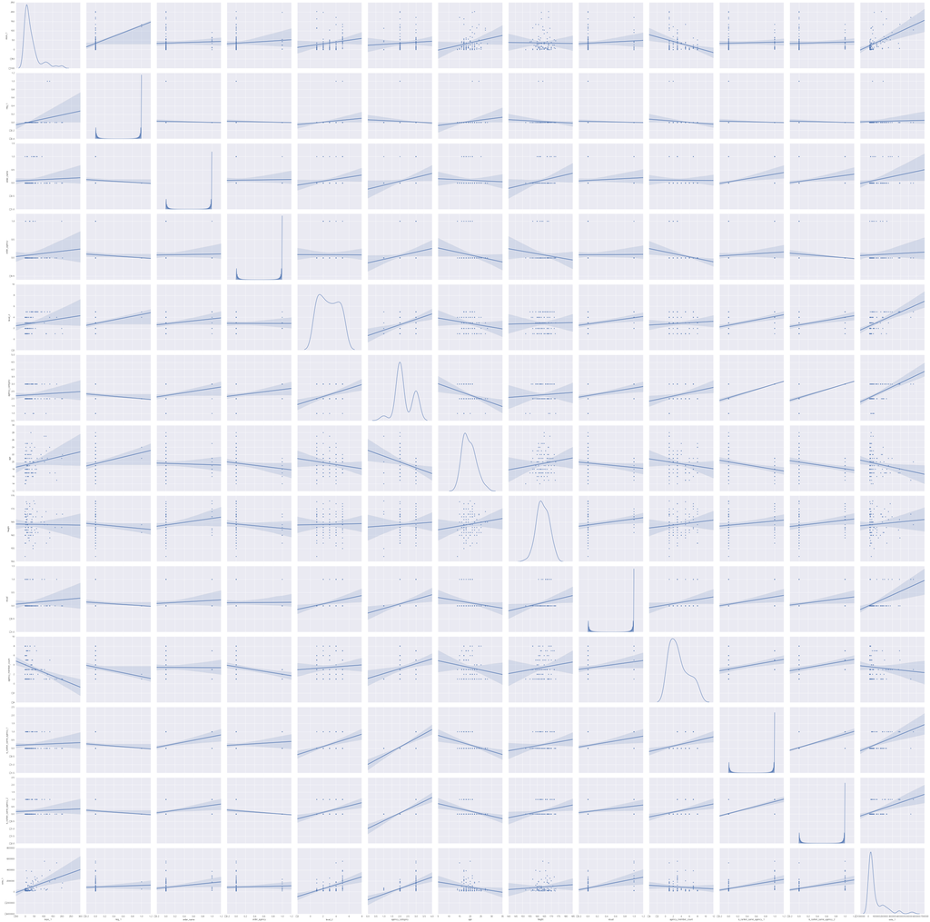

```python
# First EDA(Exploratory data analysis) with vote_1(target)

sns.pairplot(produce101_df, diag_kind="kde", kind="reg"
             ,vars = ['expo_1', 'neg_1', 'order_name', 'order_agency',
                      'level_2', 'agency_category', 'age', 'height', 'visual', 'agency_member_count'
                      ,'is_ranker_same_agency_1','is_ranker_same_agency_2', 'vote_1'], size=5)
plt.show()
```

# Machine Learning Model

- OLS Regression
  - In statistics, ordinary least squares (OLS) or linear least squares is a method for estimating the unknown parameters in a linear regression model, with the goal of minimizing the differences between the observed responses in some arbitrary dataset and the responses predicted by the linear approximation of the data (visually this is seen as the sum of the vertical distances between each data point in the set and the corresponding point on the regression line.

[figure not shown]

# Data Frame(SET)

```python
Y = produce101_df['vote_1']
Y2 = produce101_df['vote_2']
X = pd.DataFrame(produce101_df,
                 columns = ['expo_1', 'expo_2', 'neg_1', 'order_name'
                            , 'order_agency', 'level_1','level_2'
                            , 'agency_category', 'age', 'height', 'visual'
                            , 'agency_member_count', 'is_ranker_same_agency_1', 'is_ranker_same_agency_2' ])
X.head()
```

| name | expo_1 | expo_2 | neg_1 | order_name | order_agency | level_1 | level_2 | agency_category | age | height | visual | agency_member_count | is_ranker_same_agency_1 | is_ranker_same_agency_2 |
| --- | --- | --- | --- | --- | --- | --- | --- | --- | --- | --- | --- | --- | --- | --- |
| 김세정 | 105 | 104 | 0 | 0 | 0 | 5 | 5 | 3 | 20 | 164.0 | 1 | 3 | 1 | 1 |
| 전소미 | 171 | 63 | 0 | 0 | 0 | 5 | 4 | 3 | 15 | 168.0 | 1 | 1 | 0 | 0 |
| 최유정 | 134 | 71 | 0 | 0 | 0 | 2 | 5 | 3 | 17 | 159.0 | 0 | 5 | 1 | 1 |
| 주결경 | 6 | 31 | 0 | 0 | 0 | 5 | 5 | 3 | 18 | 166.0 | 1 | 7 | 1 | 1 |
| 강미나 | 34 | 100 | 0 | 1 | 0 | 5 | 5 | 3 | 17 | 162.0 | 0 | 3 | 1 | 1 |

# Preprocessing

```python
# Category 값을 제외한 실수값 preprocessing
X_prepro = X

X_prepro[['expo_1']] = scale (X[['expo_1']])
X_prepro[['expo_2']] = scale (X[['expo_2']])
X_prepro[['age']] = scale (X[['age']])
X_prepro[['height']] = scale (X[['height']])
X_prepro[['level_1']] = scale (X[['level_1']])
X_prepro[['level_2']] = scale (X[['level_2']])
X_prepro[['agency_member_count']] = scale (X[['agency_member_count']])
X_prepro
```

| name | expo_1 | expo_2 | neg_1 | order_name | order_agency | level_1 | level_2 | agency_category | age | height | visual | agency_member_count | is_ranker_same_agency_1 | is_ranker_same_agency_2 |
| --- | --- | --- | --- | --- | --- | --- | --- | --- | --- | --- | --- | --- | --- | --- |
| 김세정 | 1.577921 | 3.171328 | 0 | 0 | 0 | 1.662945 | 1.426050 | 3 | 0.149748 | -0.029856 | 1 | -0.197431 | 1 | 1 |
| 전소미 | 3.060435 | 1.638468 | 0 | 0 | 0 | 1.662945 | 0.747977 | 3 | -1.500886 | 0.911953 | 1 | -1.067920 | 0 | 0 |
| 최유정 | 2.229329 | 1.937563 | 0 | 0 | 0 | -0.567087 | 1.426050 | 3 | -0.840632 | -1.207117 | 0 | 0.673059 | 1 | 1 |
| 주결경 | -0.645850 | 0.442090 | 0 | 0 | 0 | 1.662945 | 1.426050 | 3 | -0.510505 | 0.441048 | 1 | 1.543548 | 1 | 1 |
| 강미나 | -0.016905 | 3.021780 | 0 | 1 | 0 | 1.662945 | 1.426050 | 3 | -0.840632 | -0.500761 | 0 | -0.197431 | 1 | 1 |
| 기희현 | 1.263448 | -0.006552 | 0 | 1 | 0 | 0.176257 | 1.426050 | 3 | 0.479875 | 0.676500 | 1 | -0.197431 | 1 | 1 |
| 김다니 | 0.387417 | -0.380421 | 0 | 1 | 0 | 0.919601 | 1.426050 | 3 | -0.840632 | 1.853761 | 0 | -0.197431 | 1 | 1 |
| 정채연 | -0.556001 | 0.554250 | 0 | 0 | 0 | 0.176257 | 0.069904 | 3 | -0.180379 | 0.441048 | 1 | -0.197431 | 1 | 1 |
| 김나영 | 0.679428 | 0.928118 | 0 | 1 | 0 | 1.662945 | 1.426050 | 3 | 0.479875 | 1.147405 | 0 | -0.197431 | 1 | 1 |
| 전소연 | 0.432342 | 0.292542 | 0 | 0 | 1 | 1.662945 | 1.426050 | 3 | -0.510505 | -1.678022 | 0 | -0.197431 | 1 | 0 |
| 김소혜 | 2.880736 | 4.068612 | 0 | 0 | 0 | -1.310431 | -1.286242 | 2 | -0.840632 | -0.265309 | 0 | -1.067920 | 0 | 0 |
| 유연정 | 0.522191 | 1.301987 | 0 | 0 | 0 | 0.919601 | 1.426050 | 3 | -0.840632 | 0.676500 | 0 | -0.197431 | 0 | 1 |
| 김도연 | 0.095407 | -0.604742 | 0 | 0 | 0 | 0.919601 | 1.426050 | 3 | -0.840632 | 1.382857 | 1 | 0.673059 | 1 | 1 |
| 김청하 | 0.769277 | -0.156100 | 0 | 0 | 0 | 1.662945 | 1.426050 | 2 | 0.149748 | -0.736213 | 0 | -0.632675 | 0 | 0 |
| 허찬미 | 2.206866 | 0.629024 | 1 | 0 | 0 | 1.662945 | 0.747977 | 2 | 1.470256 | -0.736213 | 0 | -1.067920 | 0 | 0 |
| 권은빈 | 0.185256 | 0.479476 | 0 | 1 | 1 | 1.662945 | -0.608169 | 3 | -1.170759 | 0.676500 | 1 | -0.197431 | 1 | 0 |
| 응 씨 카이 | -0.690775 | 1.227213 | 0 | 0 | 0 | 0.919601 | 0.747977 | 2 | 0.810002 | 0.205596 | 0 | -1.067920 | 0 | 0 |
| 정은우 | -0.623388 | 0.255155 | 0 | 0 | 0 | -0.567087 | 0.747977 | 3 | -0.510505 | 0.676500 | 0 | 1.543548 | 1 | 1 |
| 김주나 | 3.756767 | 1.601081 | 0 | 0 | 0 | 0.176257 | -1.286242 | 2 | 0.810002 | 0.911953 | 0 | -1.067920 | 0 | 0 |
| 박소연 | -0.061829 | 0.591637 | 0 | 0 | 0 | 1.662945 | 1.426050 | 3 | -0.840632 | 0.911953 | 0 | -1.067920 | 0 | 0 |
| 윤채경 | 0.185256 | 1.750628 | 0 | 0 | 1 | -0.567087 | 0.069904 | 3 | 0.149748 | -0.971665 | 0 | -0.632675 | 0 | 0 |
| 한혜리 | -0.421227 | -0.230873 | 0 | 0 | 0 | 0.176257 | -0.608169 | 3 | -0.180379 | -1.207117 | 0 | -0.197431 | 0 | 0 |
| 김소희 | -0.421227 | -0.230873 | 0 | 0 | 0 | 0.176257 | 0.069904 | 2 | 0.479875 | -0.500761 | 0 | -1.067920 | 0 | 0 |
| 임나영 | -0.241528 | -0.043939 | 0 | 0 | 0 | 0.919601 | 1.426050 | 3 | 0.479875 | 1.618309 | 0 | 1.543548 | 1 | 1 |
| 안예슬 | -0.016905 | 1.713242 | 0 | 0 | 0 | 0.919601 | 0.747977 | 2 | 0.479875 | -0.736213 | 0 | -0.632675 | 0 | 0 |
| 박시연 | -0.421227 | 1.563694 | 0 | 0 | 0 | 0.919601 | 0.747977 | 3 | -1.170759 | -0.265309 | 1 | 1.543548 | 1 | 1 |
| 조시윤 | -0.219066 | -0.455194 | 0 | 0 | 1 | -0.567087 | -0.608169 | 3 | 0.149748 | -0.971665 | 0 | -0.632675 | 0 | 0 |
| 강예빈 | 0.612041 | -0.006552 | 0 | 1 | 0 | 1.662945 | 1.426050 | 3 | -0.510505 | -0.383035 | 0 | 1.543548 | 1 | 1 |
| 윤서형 | 3.666918 | -0.567355 | 0 | 0 | 1 | -1.310431 | -0.608169 | 2 | 0.479875 | -0.265309 | 0 | -1.067920 | 0 | 0 |
| 김서경 | 0.162794 | -0.043939 | 0 | 0 | 0 | 0.919601 | 1.426050 | 1 | -0.840632 | -2.148926 | 0 | -1.067920 | 0 | 0 |
| ... | ... | ... | ... | ... | ... | ... | ... | ... | ... | ... | ... | ... | ... | ... |
| 김지성 | -0.780624 | -0.716902 | 0 | 0 | 0 | -0.567087 | 0.747977 | 2 | 0.149748 | 1.147405 | 1 | 1.978792 | 0 | 0 |
| 김수현 | -0.533538 | -0.716902 | 0 | 0 | 0 | 0.176257 | -0.608169 | 2 | -1.170759 | -0.736213 | 0 | -1.067920 | 0 | 0 |
| 최은빈 | -0.061829 | -0.716902 | 0 | 0 | 0 | 0.176257 | 0.069904 | 2 | 1.140129 | -0.265309 | 0 | -0.632675 | 0 | 0 |
| 박민지 | -0.511076 | -0.716902 | 0 | 0 | 0 | 0.919601 | 1.426050 | 2 | -0.840632 | -0.029856 | 0 | -0.632675 | 0 | 0 |
| 함예지 | -0.466151 | -0.716902 | 0 | 0 | 0 | -0.567087 | -1.286242 | 2 | 0.810002 | 0.747136 | 0 | -1.067920 | 0 | 0 |
| 김미소 | 0.072945 | -0.716902 | 0 | 0 | 0 | -0.567087 | 0.069904 | 2 | -1.170759 | 0.205596 | 0 | -0.197431 | 0 | 0 |
| 김우정 | 0.364955 | -0.716902 | 0 | 0 | 0 | 0.919601 | 0.069904 | 2 | 1.470256 | -0.500761 | 0 | 1.978792 | 0 | 0 |
| 허샘 | -0.600925 | -0.716902 | 0 | 0 | 0 | 0.176257 | -1.286242 | 2 | 1.140129 | 0.441048 | 0 | -0.197431 | 0 | 0 |
| 한지연 | -0.735699 | -0.716902 | 0 | 0 | 0 | -0.567087 | -1.286242 | 2 | 0.479875 | 0.676500 | 0 | 1.108303 | 0 | 0 |
| 니와 시오리 | -0.780624 | -0.716902 | 0 | 0 | 0 | -0.567087 | 0.747977 | 2 | 0.810002 | -0.500761 | 0 | -0.632675 | 0 | 0 |
| 편강윤 | -0.690775 | -0.716902 | 0 | 0 | 0 | -1.310431 | -1.286242 | 2 | 1.470256 | 0.864862 | 0 | -1.067920 | 0 | 0 |
| 이수현 | -0.196603 | -0.716902 | 0 | 0 | 0 | -0.567087 | 0.747977 | 2 | 0.149748 | -0.736213 | 1 | 1.978792 | 0 | 0 |
| 김홍은 | -0.758162 | -0.716902 | 0 | 0 | 0 | 0.176257 | -1.286242 | 2 | -0.840632 | 1.382857 | 0 | 1.978792 | 0 | 0 |
| 김도희 | -0.600925 | -0.716902 | 0 | 0 | 0 | -1.310431 | -1.286242 | 2 | -0.180379 | 0.205596 | 0 | 0.673059 | 0 | 0 |
| 김설아 | -0.735699 | -0.716902 | 0 | 0 | 0 | -0.567087 | -1.286242 | 2 | 1.800382 | -0.265309 | 0 | -1.067920 | 0 | 0 |
| 오한아름 | -0.578463 | -0.716902 | 0 | 0 | 0 | -1.310431 | -1.286242 | 2 | -0.510505 | -0.500761 | 0 | 0.673059 | 0 | 0 |
| 김윤지 | 0.185256 | -0.716902 | 0 | 0 | 0 | 0.176257 | 0.747977 | 3 | 0.149748 | -1.913474 | 0 | -0.197431 | 0 | 0 |
| 이서정 | -0.713237 | -0.716902 | 0 | 0 | 0 | -1.310431 | -0.608169 | 2 | -1.170759 | -0.265309 | 0 | -0.197431 | 0 | 0 |
| 김자연 | -0.488614 | -0.716902 | 0 | 0 | 0 | -1.310431 | -0.608169 | 2 | 1.800382 | -0.029856 | 0 | 1.978792 | 0 | 0 |
| 이채린 | -0.758162 | -0.716902 | 0 | 0 | 0 | -0.567087 | -0.608169 | 2 | -0.840632 | -0.500761 | 0 | 1.108303 | 0 | 0 |
| 최유빈 | -0.600925 | -0.716902 | 0 | 0 | 0 | 0.176257 | -0.608169 | 2 | -0.840632 | -0.736213 | 0 | 1.108303 | 0 | 0 |
| 캐서린 리 | -0.735699 | -0.716902 | 0 | 0 | 0 | -0.567087 | -1.286242 | 2 | -1.500886 | 0.205596 | 0 | 1.108303 | 0 | 0 |
| 신혜현 | -0.623388 | -0.716902 | 0 | 0 | 0 | -1.310431 | 0.069904 | 2 | -0.840632 | -0.500761 | 0 | 1.108303 | 0 | 0 |
| 남수진 | -0.780624 | -0.716902 | 0 | 0 | 0 | 0.176257 | 0.069904 | 2 | 0.479875 | 0.911953 | 0 | -0.632675 | 0 | 0 |
| 김솔이 | -0.645850 | -0.716902 | 0 | 0 | 0 | -1.310431 | -1.286242 | 2 | -1.500886 | 2.018578 | 0 | 0.673059 | 0 | 0 |
| 이세흔 | -0.308915 | -0.716902 | 0 | 0 | 0 | 0.919601 | 0.069904 | 2 | -0.840632 | -1.207117 | 0 | -1.067920 | 0 | 0 |
| 방준희 | -0.556001 | -0.716902 | 0 | 0 | 0 | -1.310431 | 0.069904 | 2 | -0.510505 | -0.029856 | 0 | 0.673059 | 0 | 0 |
| 윤유담 | -0.263990 | -0.716902 | 0 | 0 | 1 | 0.919601 | -0.608169 | 2 | -0.180379 | 0.911953 | 0 | -1.067920 | 0 | 0 |
| 김보선 | -0.376302 | -0.716902 | 0 | 0 | 0 | -0.567087 | -0.608169 | 2 | 0.810002 | -0.265309 | 0 | -0.197431 | 0 | 0 |
| 문현주 | -0.488614 | -0.716902 | 0 | 0 | 0 | -1.310431 | -1.286242 | 2 | -0.510505 | 1.382857 | 0 | -0.632675 | 0 | 0 |

97 rows × 14 columns

# Regression : OLS

- 속성간의 중요도나 관계를 파악하기 위한
- 해석 가능한 모델

```python
print(OLS_result(Y,X_prepro).summary())
```

```
                            OLS Regression Results
==============================================================================
Dep. Variable:                 vote_1   R-squared:                       0.854
Model:                            OLS   Adj. R-squared:                  0.830
Method:                 Least Squares   F-statistic:                     34.81
Date:                Sat, 09 Apr 2016   Prob (F-statistic):           8.41e-29
Time:                        14:06:19   Log-Likelihood:                -1194.5
No. Observations:                  97   AIC:                             2417.
Df Residuals:                      83   BIC:                             2453.
Df Model:                          14
Covariance Type:            nonrobust
===========================================================================================
                              coef    std err          t      P>|t|      [95.0% Conf. Int.]
-------------------------------------------------------------------------------------------
expo_1                    2.73e+04   7554.715      3.614      0.001      1.23e+04  4.23e+04
expo_2                   3.572e+04   7323.497      4.878      0.000      2.12e+04  5.03e+04
neg_1                   -3.775e+04   4.62e+04     -0.817      0.416      -1.3e+05  5.41e+04
order_name              -1.619e+04   2.24e+04     -0.724      0.471     -6.07e+04  2.83e+04
order_agency            -3.466e+04   2.61e+04     -1.330      0.187     -8.65e+04  1.72e+04
level_1                  1.735e+04   7373.322      2.354      0.021      2689.738   3.2e+04
level_2                  7885.8722   7729.709      1.020      0.311     -7488.207  2.33e+04
agency_category          3.307e+04   3865.333      8.556      0.000      2.54e+04  4.08e+04
age                     -9424.6295   6509.461     -1.448      0.151     -2.24e+04  3522.426
height                   5423.3900   6387.223      0.849      0.398     -7280.540  1.81e+04
visual                    8.14e+04    2.1e+04      3.878      0.000      3.96e+04  1.23e+05
agency_member_count     -1.533e+04   6969.941     -2.200      0.031     -2.92e+04 -1468.910
is_ranker_same_agency_1  5.699e+04    3.1e+04      1.837      0.070     -4710.917  1.19e+05
is_ranker_same_agency_2 -6887.4651   2.96e+04     -0.233      0.817     -6.58e+04   5.2e+04
==============================================================================
Omnibus:                        3.292   Durbin-Watson:                   1.475
Prob(Omnibus):                  0.193   Jarque-Bera (JB):                3.501
Skew:                          -0.028   Prob(JB):                        0.174
Kurtosis:                       3.929   Cond. No.                         19.0
==============================================================================

Warnings:
[1] Standard Errors assume that the covariance matrix of the errors is correctly specified.
```

# Collinearity(공선성) 확인

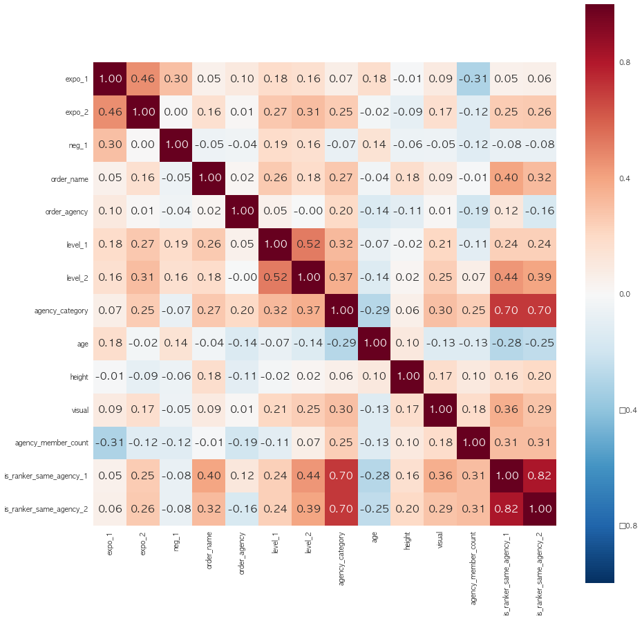

```python
plt.figure(figsize=(15, 15))
sns.heatmap(np.corrcoef(X_prepro.T), annot=True, square=True, fmt='.2f', annot_kws={'size':15},
            yticklabels=X_prepro.columns, xticklabels=X_prepro.columns)
```

# Collinearity Review

# 1) Feature selection with pure profile

```python
X_prepro_profile = X_prepro.drop(labels = ['expo_1', 'expo_2', 'neg_1', 'order_name', 'order_agency'
                                           , 'level_1', 'height', 'age', 'agency_member_count'
                                           , 'is_ranker_same_agency_1', 'is_ranker_same_agency_1', 'is_ranker_same_agency_2'], axis=1)
print( OLS_result(Y, X_prepro_profile).summary() )
```

```
                            OLS Regression Results
==============================================================================
Dep. Variable:                 vote_1   R-squared:                       0.664
Model:                            OLS   Adj. R-squared:                  0.653
Method:                 Least Squares   F-statistic:                     61.94
Date:                Sat, 09 Apr 2016   Prob (F-statistic):           3.46e-22
Time:                        14:06:21   Log-Likelihood:                -1235.0
No. Observations:                  97   AIC:                             2476.
Df Residuals:                      94   BIC:                             2484.
Df Model:                           3
Covariance Type:            nonrobust
===================================================================================
                      coef    std err          t      P>|t|      [95.0% Conf. Int.]
-----------------------------------------------------------------------------------
level_2          3.727e+04   8683.480      4.292      0.000         2e+04  5.45e+04
agency_category  3.523e+04   3939.152      8.944      0.000      2.74e+04  4.31e+04
visual           1.135e+05   2.79e+04      4.060      0.000       5.8e+04  1.69e+05
==============================================================================
Omnibus:                       30.325   Durbin-Watson:                   0.898
Prob(Omnibus):                  0.000   Jarque-Bera (JB):               59.561
Skew:                           1.223   Prob(JB):                     1.17e-13
Kurtosis:                       5.958   Cond. No.                         7.77
==============================================================================

Warnings:
[1] Standard Errors assume that the covariance matrix of the errors is correctly specified.
```

# Accuracy = :(

# But I realize pure profile affect to vote

```python
# 추정값 확인
model_OLS = sm.OLS(Y, X_prepro_profile)
result_OLS = model_OLS.fit()
prediction = result_OLS.fittedvalues
print_full(prediction.sort_values(ascending=False).head(11))
```

```
name
김세정    272298.822531
주결경    272298.822531
김도연    272298.822531
기희현    272298.822531
박시연    247030.031075
전소미    247030.031075
정채연    221761.239619
김지성    211797.514285
이수현    211797.514285
권은빈    196492.448163
서혜린    161259.931374
dtype: float64
```

# Outlier detection

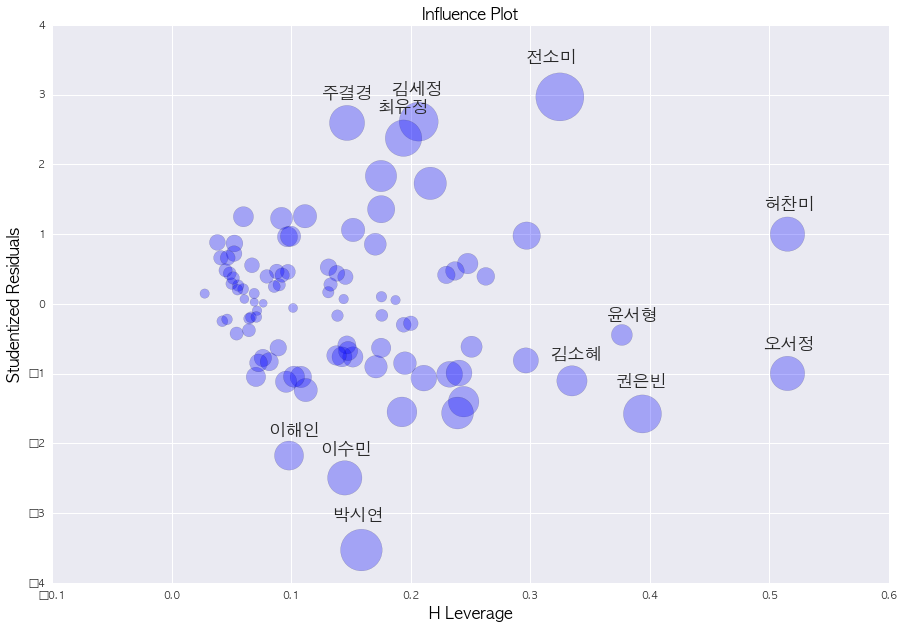

```python
fig, ax = plt.subplots(figsize=(15, 10))
sm.graphics.influence_plot( OLS_result(Y, X_prepro), plot_alpha=0.3, ax=ax)
plt.show()

# 질문 feature가 8개 이상이면 influence_plot을 못그린다?!
```

# 2) Feature Selection with Focusing Broadcast&Agency (carry)

## 2-1) Before Outlier Removal

```python
X_prepro_carry = X_prepro.drop(labels = ['level_1',], axis=1)
print( OLS_result(Y, X_prepro_carry).summary() )
```

```
                            OLS Regression Results
==============================================================================
Dep. Variable:                 vote_1   R-squared:                       0.845
Model:                            OLS   Adj. R-squared:                  0.821
Method:                 Least Squares   F-statistic:                     35.16
Date:                Sat, 09 Apr 2016   Prob (F-statistic):           1.89e-28
Time:                        14:06:21   Log-Likelihood:                -1197.6
No. Observations:                  97   AIC:                             2421.
Df Residuals:                      84   BIC:                             2455.
Df Model:                          13
Covariance Type:            nonrobust
===========================================================================================
                              coef    std err          t      P>|t|      [95.0% Conf. Int.]
-------------------------------------------------------------------------------------------
expo_1                   2.695e+04   7754.660      3.475      0.001      1.15e+04  4.24e+04
expo_2                   3.721e+04   7490.643      4.968      0.000      2.23e+04  5.21e+04
neg_1                   -2.311e+04    4.7e+04     -0.492      0.624     -1.17e+05  7.03e+04
order_name              -5429.5761   2.25e+04     -0.242      0.810     -5.01e+04  3.92e+04
order_agency            -2.972e+04   2.67e+04     -1.114      0.268     -8.28e+04  2.33e+04
level_2                  1.575e+04   7157.097      2.200      0.031      1513.119     3e+04
agency_category          3.226e+04   3952.483      8.161      0.000      2.44e+04  4.01e+04
age                     -9732.1948   6681.716     -1.457      0.149      -2.3e+04  3555.129
height                   4556.5254   6546.655      0.696      0.488     -8462.215  1.76e+04
visual                   8.798e+04   2.14e+04      4.119      0.000      4.55e+04   1.3e+05
agency_member_count     -1.714e+04   7112.157     -2.410      0.018     -3.13e+04 -2998.147
is_ranker_same_agency_1  4.812e+04   3.16e+04      1.522      0.132     -1.47e+04  1.11e+05
is_ranker_same_agency_2   849.4499   3.02e+04      0.028      0.978     -5.92e+04  6.09e+04
==============================================================================
Omnibus:                        4.729   Durbin-Watson:                   1.446
Prob(Omnibus):                  0.094   Jarque-Bera (JB):                6.413
Skew:                           0.021   Prob(JB):                       0.0405
Kurtosis:                       4.259   Cond. No.                         18.7
==============================================================================

Warnings:
[1] Standard Errors assume that the covariance matrix of the errors is correctly specified.
```

## After feature selection

```python
X_prepro_carry1 = X_prepro_carry.drop(labels = ['neg_1', 'order_agency', 'order_name'
                                                ,'height', 'age', 'is_ranker_same_agency_1'], axis=1)
print( OLS_result(Y, X_prepro_carry1).summary() )
```

```
                            OLS Regression Results
==============================================================================
Dep. Variable:                 vote_1   R-squared:                       0.835
Model:                            OLS   Adj. R-squared:                  0.822
Method:                 Least Squares   F-statistic:                     65.03
Date:                Sat, 09 Apr 2016   Prob (F-statistic):           1.81e-32
Time:                        14:06:21   Log-Likelihood:                -1200.6
No. Observations:                  97   AIC:                             2415.
Df Residuals:                      90   BIC:                             2433.
Df Model:                           7
Covariance Type:            nonrobust
===========================================================================================
                              coef    std err          t      P>|t|      [95.0% Conf. Int.]
-------------------------------------------------------------------------------------------
expo_1                   2.305e+04   7144.347      3.227      0.002      8858.435  3.72e+04
expo_2                   3.812e+04   7212.680      5.285      0.000      2.38e+04  5.24e+04
level_2                  1.748e+04   6799.011      2.571      0.012      3973.974   3.1e+04
agency_category          3.051e+04   3449.552      8.845      0.000      2.37e+04  3.74e+04
visual                    9.87e+04   2.05e+04      4.808      0.000      5.79e+04  1.39e+05
agency_member_count     -1.471e+04   6847.414     -2.148      0.034     -2.83e+04 -1106.192
is_ranker_same_agency_2  4.636e+04   1.88e+04      2.466      0.016      9016.573  8.37e+04
==============================================================================
Omnibus:                        5.245   Durbin-Watson:                   1.325
Prob(Omnibus):                  0.073   Jarque-Bera (JB):                7.124
Skew:                           0.139   Prob(JB):                       0.0284
Kurtosis:                       4.298   Cond. No.                         8.14
==============================================================================

Warnings:
[1] Standard Errors assume that the covariance matrix of the errors is correctly specified.
```